# Association between Heart Disease(CAD) and Blood Pressure

Zackary Petrasek

September 29th, 2026

# 1 Introduction

High blood pressure is known to be a predictor for Coronary Artery Disease (CAD), the most common form of heart disease. CAD is caused by the build up of plaque in the arteries. As, high blood pressure wears on the inner lining which accelerates plaque build up in arteries, it makes it one of the best initial indicators for CAD. While there can be other reasons for this build up to start, such as smoking, managing your blood pressure is a great way to lower your risk of CAD.

# 2 Data Source

The heart disease data set in this case study contains 1025 observations on 14 variables. The data set is originates from the UCI machine learning data repository. However, I accessed the data from kaggle (https://www.kaggle.com/datasets/johnsmith88/heart-disease-dataset), as the data was not all processed in the UCI data repository. The data combines from four databases from Cleveland, Hungary, SWitzerland, and Long Beach V.

There are 14 variables in the data set.

1. **age**: Age in years(discrete, numeric)
2. **sex**: 1 if male, 0 if female(binary, categorical)
3. **cp**: Chest pain type, 1 is typical angina, 2 is atypical angina, 3 is non-anginal, 4 is asymptomatic (4-level, categorical)
4. **bp**: Resting systolic blood pressure (discrete, numeric, in mmHg)
5. **chol**: Serum cholesterol (discrete, numeric, in mg/dl)
6. **fbs**: Fasting blood pressure, 1 if 120 mg/dl, 0 if not (binary, categorical)
7. **ecg**: Resting electrocardiograph results, 2 if showing probable or definite left ventricular hypertrophy(by Estes’ criteria), 1 if having ST-T wave abnormality(T wave inversions and/or ST elevation or depression greater than .05 mV), 0 if normal. (Three-level, catagorical)
8. **maxbpm**: Maximum heart beat (discrete, numeric, BpM)
9. **exang**: Exercise induced angina, 1 if yes, 0 if no (binary, catagorical)
10. **oldpeak**: ST depression induced by exercise relative to rest (continuous, numeric, mm)
11. **slope**: Slope of the peak exercise ST segment, 3 if downslopping, 2 if flat, 1 if upsloping. (Three-level, catagorical)
12. **ca**: Number of major vessels colored by flourosopy, 0, 1, 2, 3. (discret, numeric)
13. **thal**: Thalassemia status, 3 if normal, 6 if fixed defect, 7 if reverseable defect.
14. **CAD**: Testing variable (test for CAD results, binary, categorical)

The following code loads the heart disease datatset and assesses for missingness.

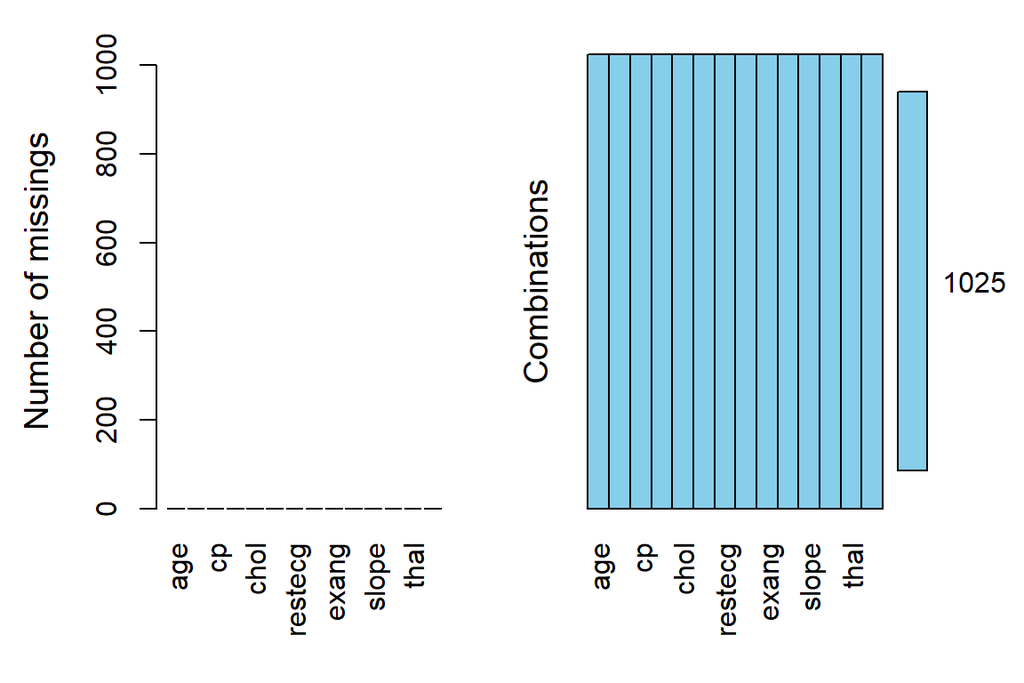

```
 Variables sorted by number of missings:
 Variable Count
      age     0
      sex     0
       cp     0
 trestbps     0
     chol     0
      fbs     0
  restecg     0
  thalach     0
    exang     0
  oldpeak     0
    slope     0
       ca     0
     thal     0
   target     0
```

```r
library(readr)
library(VIM)
#Read in data set
url <- "https://raw.githubusercontent.com/ZackaryPetrasek/STA321/main/homeworks/hw4/heart.csv"
heart <- read_csv(url)
#Look at missingness in the data
aggr(heart, numbers = TRUE, prop = FALSE, sortVar = TRUE)
```

```r
#Rename variables to make them easier to weave into thr narrative
names(heart)[c(4,7,8,14)] <- c("bp", "ecg", "maxbpm", "CAD")
```

As there is no missing values in the data set, we can continue using the full data set of 1025 observations.

# 3 Clinical Question

Many studies indicated that high blood pressure is a more powerful risk factor for CAD than family history. The objective of this case study is to explore the **association** between blood pressure and CAD.

The general interpretation of systolic blood pressure for adults is given below:

- **Low BP**: < 90
- **Normal and Healthy BP**: [90, 120]
- **Elevated BP**: [120, 129]
- **Stage 1 hypertension**: [130, 139]
- **Stage 2 hypertension**: [140, 179]
- **Hypertensive crisis**: > 180

In this study, we focus only on simple logistic regression modeling, we stay with the original (continuous) numerical variable bp. The above discretization will be used in the case study in the next note.

# 4 Exploratory Data Analysis

Since we only study the simple logistic regression model, only one predictor variable is included in the model. We first perform exploratory data analysis on the predictor variable to make sure the variable is not extremely skewed.

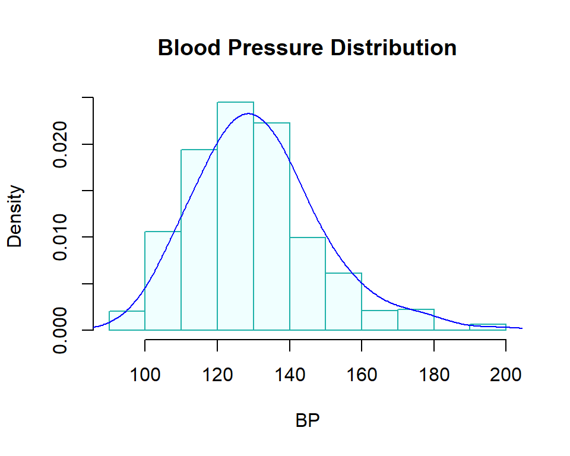

```r
ylimit = max(density(heart$bp)$y)   # find the highest point on the density curve.
#Plot a histogram with a line representing density of values of blood pressure
hist(heart$bp, probability = TRUE,
     main = "Blood Pressure Distribution",
     xlab="BP",
     col = "azure1",
     border="lightseagreen")
  lines(density(heart$bp, adjust=2), col="blue")
```

The histogram above shows that the BP distribution is slightly right-skewed. However, no transformation is necessary for this predictor variable at this stage.

Exploratory Data Analysis (EDA) for other variables will be performed in a subsequent case study on multiple logistic regression, as needed.

# 5 Building Logistic Regression Model

Since the simple logistic regression contains only one continuous variable of a binary categorical variable as the predictor variable, no there is no issue of potential imbalance. We will not transform BP and fit a logistic regression directly to the data.

```r
#Create the logistic regression model
s.logit = glm(CAD ~ bp,
          family = binomial(link = "logit"),
          data = heart)
```

The summary of major statistics is given below.

```r
#Gather the information from the summary of the model and report it in a table, along with 95% CI
model.coef.stats = summary(s.logit)$coef
conf.ci = confint(s.logit)
sum.stats = cbind(model.coef.stats, conf.ci.95=conf.ci)
pander(sum.stats,caption = "The summary stats of regression coefficients")
```

The summary stats of regression coefficients (continued below)

|  | Estimate | Std. Error | z value | Pr(>\|z\|) | 2.5 % |
| --- | --- | --- | --- | --- | --- |
| **(Intercept)** | 2.188 | 0.4904 | 4.462 | 8.125e-06 | 1.235 |
| **bp** | -0.01623 | 0.003698 | -4.388 | 1.145e-05 | -0.02356 |

|  | 97.5 % |
| --- | --- |
| **(Intercept)** | 3.16 |
| **bp** | -0.009046 |

Despite the known known positive association between the two variables the data set actually show a negative association, with ($\beta_1$) being -0.01623. a a p value less than 0.001. The p-value is supported by the 95% confidence interval of ($\beta_1$) being [-0.02356, -0.009046].

From a practical perspective, it is more common to interpret the results using the odds ratio. Therefore, we now convert the estimated regression coefficients into odds ratios.

```r
#Make table with Odds ratio
model.coef.stats = summary(s.logit)$coef
odds.ratio = exp(coef(s.logit))
out.stats = cbind(model.coef.stats, odds.ratio = odds.ratio)
pander(out.stats,caption = "Summary Stats with Odds Ratios")
```

Summary Stats with Odds Ratios

|  | Estimate | Std. Error | z value | Pr(>\|z\|) | odds.ratio |
| --- | --- | --- | --- | --- | --- |
| **(Intercept)** | 2.188 | 0.4904 | 4.462 | 8.125e-06 | 8.918 |
| **bp** | -0.01623 | 0.003698 | -4.388 | 1.145e-05 | 0.9839 |

Several global goodness-of-fit measures for the model are summarized in the following table.

```r
## Create global goodness-of-fit chart
dev.resid = s.logit$deviance
dev.0.resid = s.logit$null.deviance
aic = s.logit$aic
goodness = cbind(Deviance.residual =dev.resid, Null.Deviance.Residual = dev.0.resid,
      AIC = aic)
pander(goodness)
```

| Deviance.residual | Null.Deviance.Residual | AIC |
| --- | --- | --- |
| 1400 | 1420 | 1404 |

Since the above global goodness-of-fit is based on the **log-likelihood (LL) function**, we don’t have other candidate models with corresponding likelihood at the same scale to compare in this simple logistic regression model, we will not interpret these goodness-of-fit measures.

**Comments**: Definitions of key terms for understanding the output.

1. The **Saturated Model** is a model that assumes each data point has its own parameters (which means you have n parameters to estimate.)
2. The **Null Model** assumes the exact “opposite”, in that is assumes one parameter for all of the data points, which means you only estimate 1 parameter.
3. The **Proposed Model** assumes you can explain your data points with $p$ parameters $+$ an intercept term, so you have $p+1$ parameters.
4. **log-likelihood**: In simple terms, the log-likelihood is a measure of how well a statistical model fits a set of data. A higher (less negative) log-likelihood indicates a better fit.
5. **-2 Log-Likelihood (-2LL)**: Multiplying by 2 gives us a statistic whose sampling distribution is known and very useful.
6. **Null Deviance** = $2(LL(\text{Saturated Model}) - LL(\text{Null Model}))$ on $df = df_\text{Sat} - df_\text{Null}$
7. **Residual Deviance** = $2(LL(\text{Saturated Model}) - LL(\text{Proposed Model}))$ with $df = df_\text{Sat} - df_\text{Proposed}$

It is important to know that both **Null Deviance** and **Residual Deviance** are asymptotic $\chi^2_{df}$!

If your Null Deviance is really small, it means that the Null Model explains the data pretty well. Likewise with your Residual Deviance.

The success probability curve (so-called S curve) is given below.

[figure not shown]

```r
#Create variables based on the data to make the process of making the plots easier
bp.range = range(heart$bp)
x = seq(bp.range[1], bp.range[2], length = 200)
beta.x = coef(s.logit)[1] + coef(s.logit)[2]*x
success.prob = exp(beta.x)/(1+exp(beta.x))
failure.prob = 1/(1+exp(beta.x))
ylimit = max(success.prob, failure.prob)
beta1 = coef(s.logit)[2]
success.prob.rate = beta1*exp(beta.x)/(1+exp(beta.x))^2

#Create the first s plot based on our model to look at the probability of CAD based on blood pressure
par(mfrow = c(1,2))
plot(x, success.prob, type = "l", lwd = 2, col = "navy",
     main = "The probability of being \n  tested positive in diabetes",
     ylim=c(0, 1.1*ylimit),
     xlab = "Bloor Pressure",
     ylab = "Probability",
     axes = FALSE,
     col.main = "navy",
     cex.main = 0.8)
axis(1, pos = 0)
axis(2)
#Create a rate of change plot for the probability to see how the rate changes for different values of blood pressure
y.rate = max(success.prob.rate)
plot(x, success.prob.rate, type = "l", lwd = 2, col = "navy",
     main = "The rate of change in the probability \n  of being tested positive for CAD",
     xlab = "Blood Pressure",
     ylab = "Rate of Change",
     ylim=c(0,2*y.rate),
     axes = FALSE,
     col.main = "navy",
     cex.main = 0.8
     )
axis(1, pos = 0)
axis(2)
```

# 6 Conclusion and Discussion